# Technical Appendix: Welfare State and Risk Perceptions, Part III

Nate Breznau

5/18/2020

This is an HTML output of an analysis of public concern about the Covid-19 pandemic and various socioeconomic factors at the country-level. The statistical analysis is performed in R Studio and this is an R Markdown file that it produces.

You will find all of the data files plus the original R code on the Open Science Framework: https://osf.io/muhdz/

```r
rm(list = ls(all = TRUE))

wd <- "C:/data" #set your working directory here

wdir <- function(x){
  paste(wd,x, sep = "/")
}


# this is a function to remove missing data
completeFun <- function(data, desiredCols) {
  completeVec <- complete.cases(data[, desiredCols])
  return(data[completeVec, ])
}


# need pacman package installed to run this
# install.packages("pacman")
pacman::p_load("dplyr","countrycode","car","ggplot2","jtools","sjPlot","sjmisc","sjlabelled","tidyverse","psych","lavaan","kable","kableExtra","ggrepel","stringi","margins", "ragg")
```

The files

cis_clean.Rmd covid_i_stress.Rmd

produce the cis2.Rdata file for analysis here.

Figure 1 and the correlation tables are produced in covid_i_stress.Rmd.

```r
load(file = wdir("COVIDiSTRESS/cis2.Rdata"))
```

### Figure 1. Outbreak Severity by Country and Day

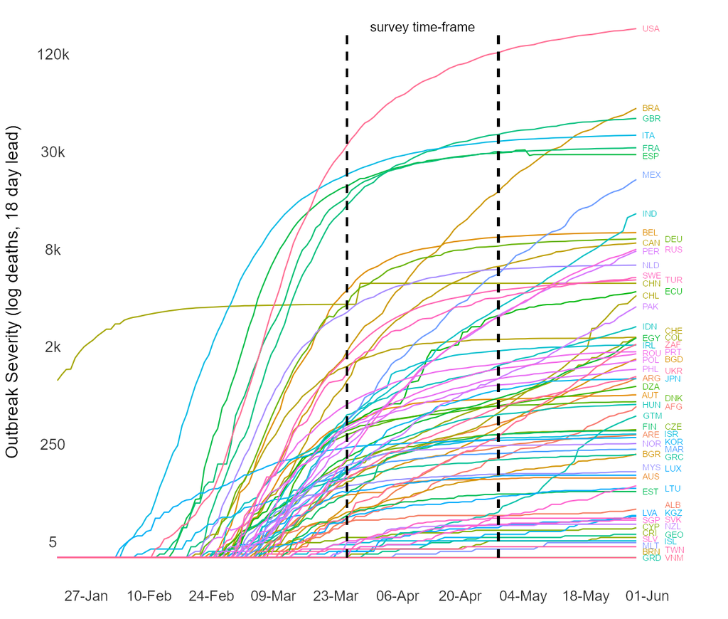

```r
knitr::include_graphics(wdir("COVIDiSTRESS/Fig1.png"))
```

### Table 1. Descriptive Correlations and Model Indices

Taken from covid_i_stress.Rmd https://osf.io/cbep2/

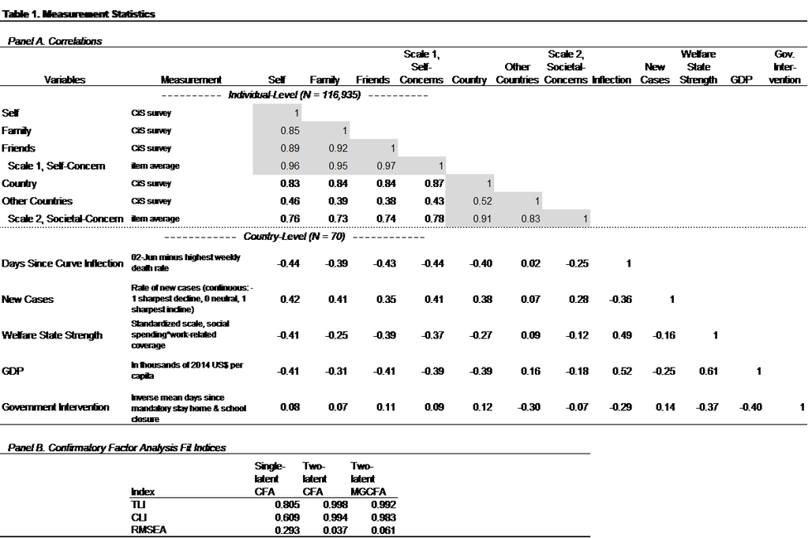

Table_1

### Fig A. Covid-19 Two Types of Concern, by Country

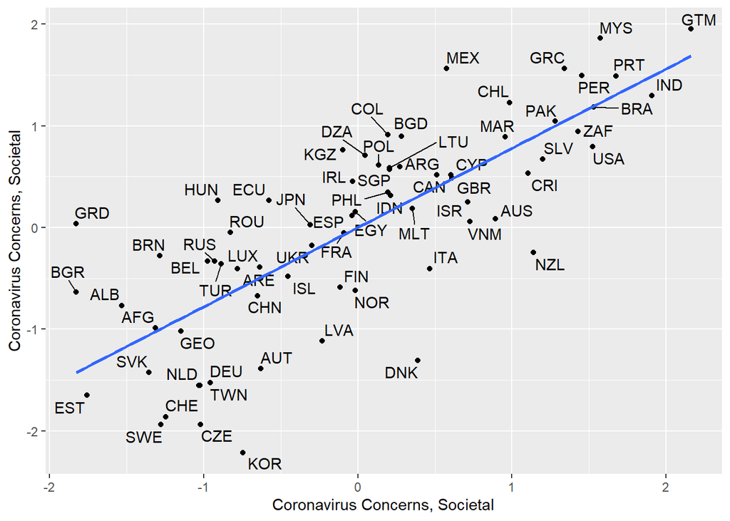

```r
ggplot(data=finaldf_C, aes(x=concern_society , y=concern_self)) +
  geom_point() +
  geom_text_repel(aes(label = iso)) +
  geom_smooth(method=lm, se=FALSE) +
  labs(x= "Coronavirus Concerns, Societal", y = "Coronavirus Concerns, Societal")
```

### Fig B. Days Since Peak and Self Concern by Country

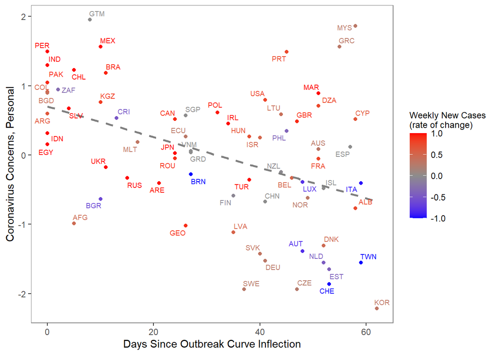

```r
mid <- 0
ggplot(data=finaldf_C, aes(x=days_since_peak, y=concern_self, color = conf_delta)) +
  geom_point() +
  geom_smooth(method=lm, se=FALSE, color = "gray50", linetype = "dashed") +
  geom_text_repel(aes(label = iso), size = 2.5) +
  scale_color_gradient2(midpoint=mid, low="blue", mid="gray55", high="red", space="Lab") +
  labs(x= "Days Since Outbreak Curve Inflection", y = "Coronavirus Concerns, Personal", color = "Weekly New Cases\n(rate of change)") +
      theme(panel.background = element_rect(fill = "white", colour = "grey50"),
        panel.grid.major = element_blank(),
        panel.grid.minor = element_blank(),
        legend.title = element_text(size = 9))
```

### Fig C. Days Since Peak and Society Concern by Country

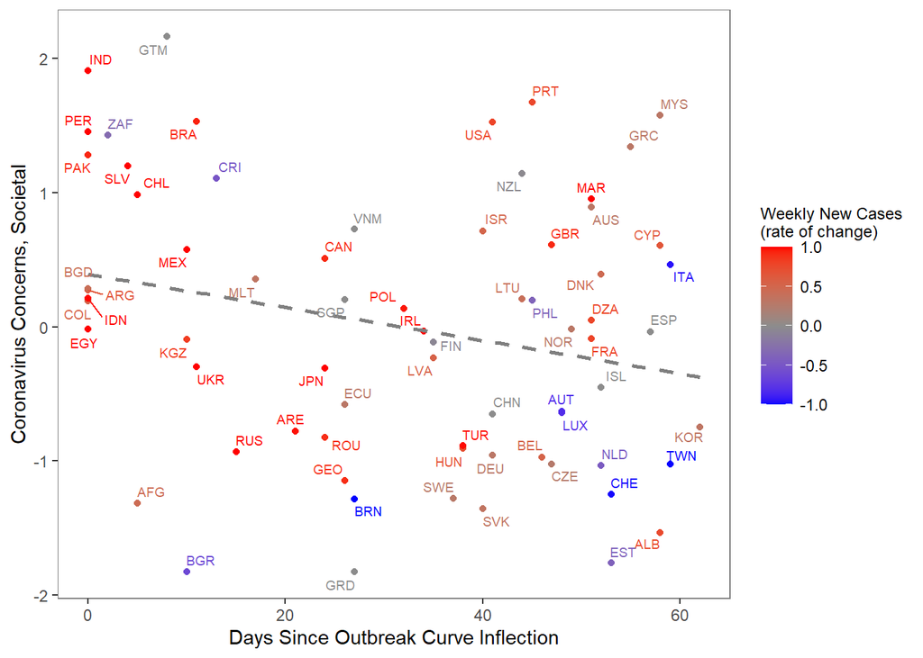

```r
mid <- 0
ggplot(data=finaldf_C, aes(x=days_since_peak, y=concern_society, color = conf_delta)) +
  geom_point() +
  geom_smooth(method=lm, se=FALSE, color = "gray50", linetype = "dashed") +
  geom_text_repel(aes(label = iso), size = 2.5) +
  scale_color_gradient2(midpoint=mid, low="blue", mid="gray55", high="red", space="Lab") +
  labs(x= "Days Since Outbreak Curve Inflection", y = "Coronavirus Concerns, Societal", color = "Weekly New Cases\n(rate of change)") +
      theme(panel.background = element_rect(fill = "white", colour = "grey50"),
        panel.grid.major = element_blank(),
        panel.grid.minor = element_blank(),
        legend.title = element_text(size = 9))
```

```r
agg_png(file = wdir("COVIDiSTRESS/Fig2.png"), width = 1000, height = 700, res = 144)
mid <- 34
ggplot(data=finaldf_C, aes(x=socpolicy, y=concern_self, color=days_since_peak)) +
  geom_point() +
  geom_smooth(method=lm, se=FALSE, color = "gray50", linetype = "dashed") +
  geom_text_repel(aes(label = iso), size = 3.5) +
  scale_color_gradient2(midpoint=mid, low="red", mid="gray55", high="blue", space="Lab") +
  labs(x= "Welfare State Strength, spending and coverage", y = "Coronavirus Concerns, Personal", color = "Days Since\nCurve Inflection") +
      theme(panel.background = element_rect(fill = "white", colour = "grey50"),
        panel.grid.major = element_blank(),
        panel.grid.minor = element_blank(),
        legend.title = element_text(size = 14),
        axis.title = element_text(size = 14),
        legend.text = element_text(size = 14))
dev.off()
```

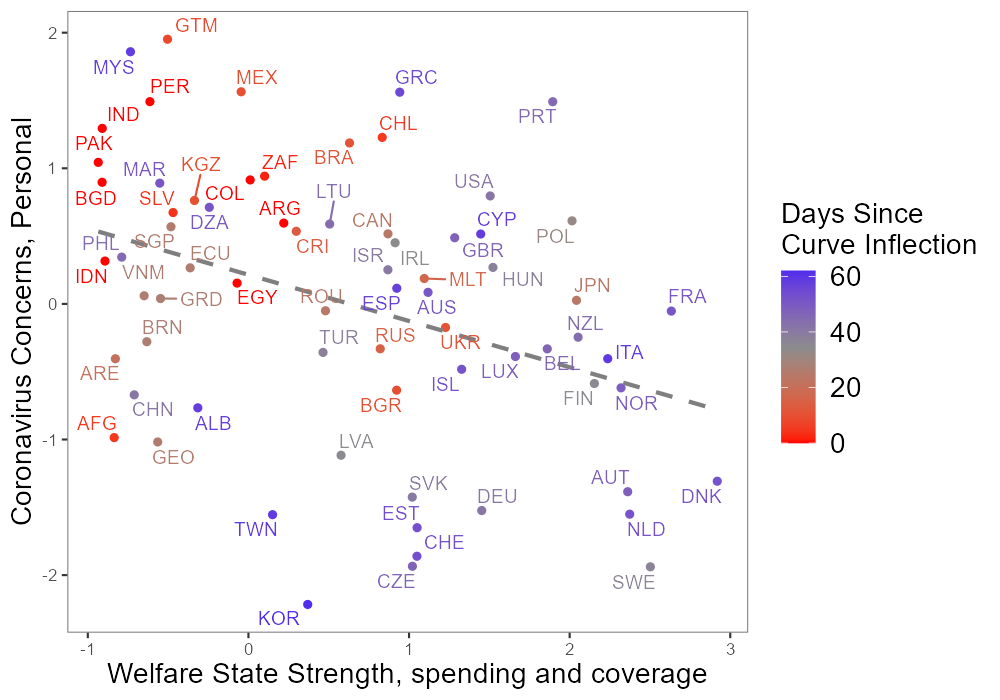

```r
knitr::include_graphics(wdir("COVIDiSTRESS/Fig2.png"))
```

### Fig 3. Welfare State Strength and Covid Concern Society by Country

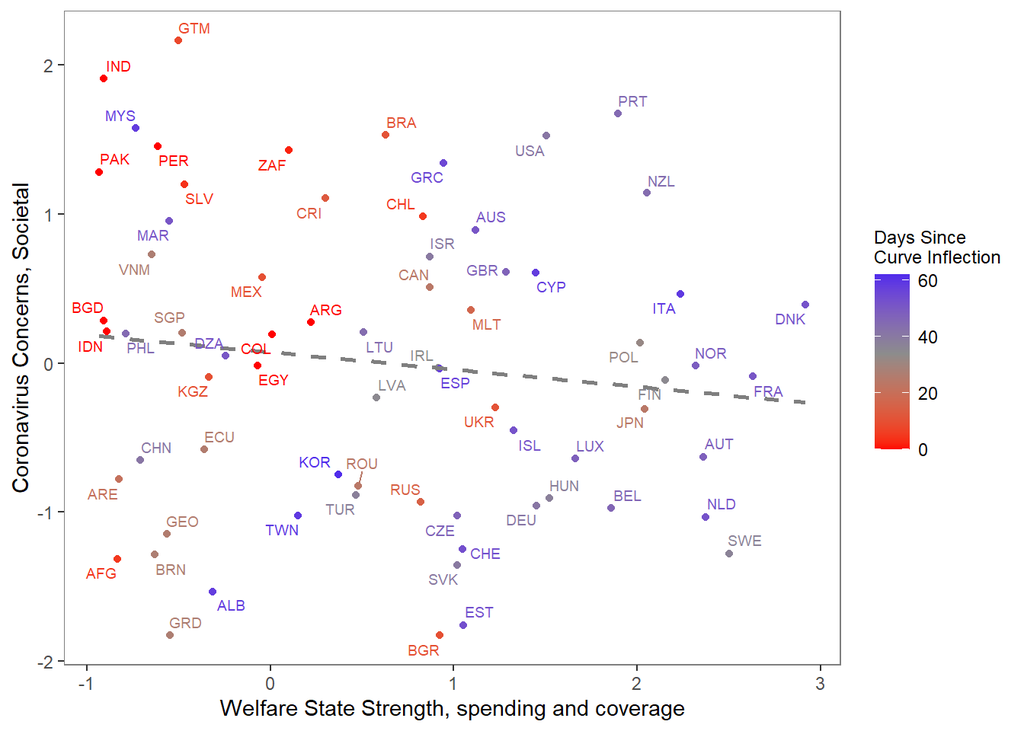

```r
mid <- 34
ggplot(data=finaldf_C, aes(x=socpolicy, y=concern_society, color=days_since_peak)) +
  geom_point() +
  geom_smooth(method=lm, se=FALSE, color = "gray50", linetype = "dashed") +
  geom_text_repel(aes(label = iso), size = 2.5) +
  scale_color_gradient2(midpoint=mid, low="red", mid="gray55", high="blue", space="Lab") +
  labs(x= "Welfare State Strength, spending and coverage", y = "Coronavirus Concerns, Societal", color = "Days Since\nCurve Inflection") +
      theme(panel.background = element_rect(fill = "white", colour = "grey50"),
        panel.grid.major = element_blank(),
        panel.grid.minor = element_blank(),
        legend.title = element_text(size = 9))
```

#### Fig D. Government Intervention and Personal Concerns

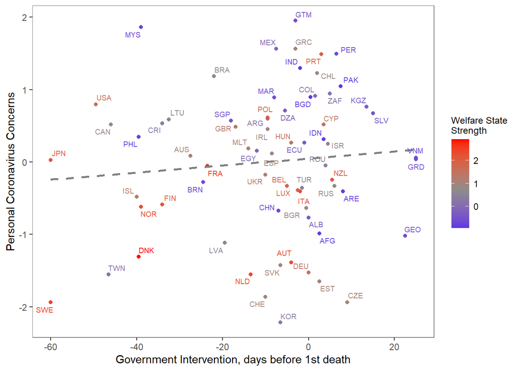

```r
mid <- 0.7

ggplot(data=finaldf_C, aes(x=intervention, y=concern_self, color=socpolicy)) +
  geom_point() +
  geom_smooth(method=lm, se=FALSE, color = "gray50", linetype = "dashed") +
  geom_text_repel(aes(label = iso), size = 2.5) +
  scale_color_gradient2(midpoint=mid, low="blue", mid="gray55", high="red", space="Lab") +
  labs(x= "Government Intervention, days before 1st death", y = "Personal Coronavirus Concerns", color = "Welfare State\nStrength") +
      theme(panel.background = element_rect(fill = "white", colour = "grey50"),
        panel.grid.major = element_blank(),
        panel.grid.minor = element_blank(),
        legend.title = element_text(size = 9))
```

#### Fig E. Government Intervention and Societal Concerns

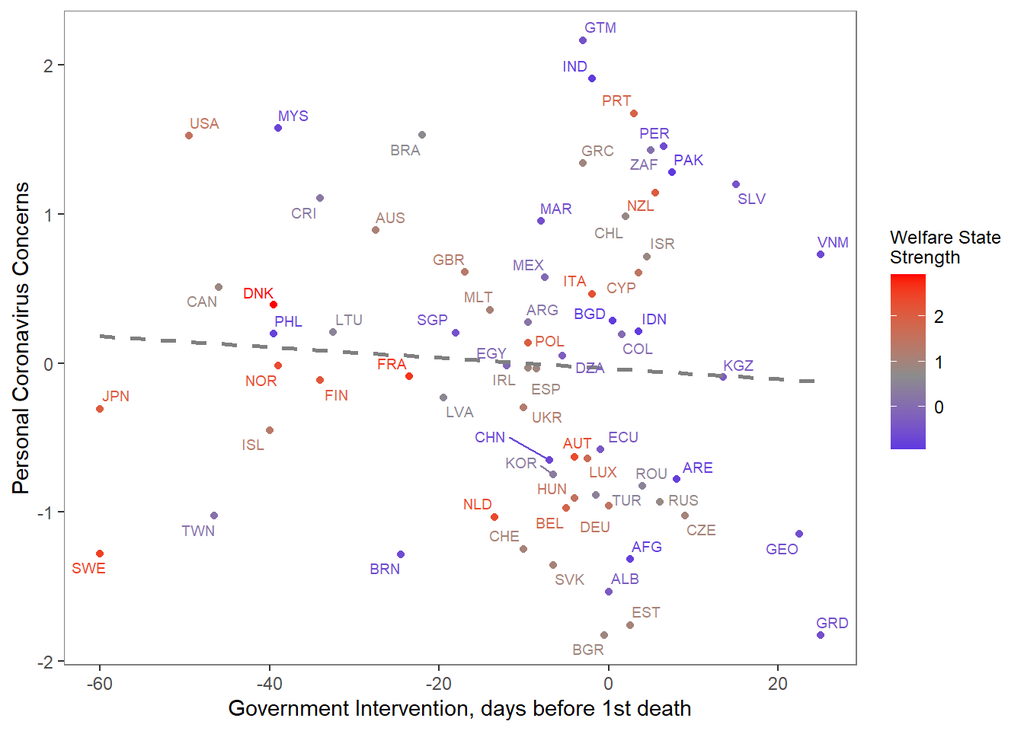

```r
mid <- 0.7

ggplot(data=finaldf_C, aes(x=intervention, y=concern_society, color=socpolicy)) +
  geom_point() +
  geom_smooth(method=lm, se=FALSE, color = "gray50", linetype = "dashed") +
  geom_text_repel(aes(label = iso), size = 2.5) +
  scale_color_gradient2(midpoint=mid, low="blue", mid="gray55", high="red", space="Lab") +
  labs(x= "Government Intervention, days before 1st death", y = "Personal Coronavirus Concerns", color = "Welfare State\nStrength") +
      theme(panel.background = element_rect(fill = "white", colour = "grey50"),
        panel.grid.major = element_blank(),
        panel.grid.minor = element_blank(),
        legend.title = element_text(size = 9))
```

## Regressions

### Table 2. Regression Models, Personal Concerns

```r
m1 <- lm(concern_self ~ days_since_peak + conf_delta, data = finaldf_C)
m2 <- lm(concern_self ~ days_since_peak + conf_delta + gdp, data = finaldf_C)
m3 <- lm(concern_self ~ days_since_peak + conf_delta + socpolicy, data = finaldf_C)
m4 <- lm(concern_self ~ days_since_peak + conf_delta + intervention*gdp, data = finaldf_C)
m5 <- lm(concern_self ~ days_since_peak + conf_delta + intervention*socpolicy, data = finaldf_C)

tab_model(m1, m2, m3, m4, m5, p.style = "stars", p.threshold = c(0.10, 0.05, 0.01), show.ci = F, rm.terms = c("(Intercept)"),  dv.labels = c("M1", "M2","M3","M4", "M5"), pred.labels = c("Days Since Curve Inflection", "New Cases",  "GDP", "Welfare State Strength", "Government Intervention", "Intervention*GDP", "Intervention*Welfare State"), file = wdir("Tbl2.html"))
```

M1

M2

M3

M4

M5

Predictors

Estimates

Estimates

Estimates

Estimates

Estimates

Days Since Curve Inflection

-0.02 ***

-0.01 *

-0.01 *

-0.01 **

-0.02 ***

New Cases

0.49 **

0.47 **

0.50 ***

0.50 **

0.64 ***

GDP

-0.01

-0.01

Welfare State Strength

-0.19 *

-0.01

Government Intervention

-0.02

-0.02 **

Intervention*GDP

0.00

Intervention*Welfare State

0.01 ***

Observations

70

70

70

70

70

R<sup>2</sup> / R<sup>2</sup> adjusted

0.266 / 0.245

0.296 / 0.264

0.300 / 0.268

0.319 / 0.266

0.397 / 0.350

- p<0.1 ** p<0.05 *** p<0.01

#### Model X. reviewer requested model with intervention alone

```r
m3x <- lm(concern_self ~ days_since_peak + conf_delta + intervention, data = finaldf_C)

tab_model(m3x)
```

|  | concern_self |  |  |
| --- | --- | --- | --- |
| Predictors | Estimates | CI | p |
| (Intercept) | 0.34 | -0.14 – 0.82 | 0.160 |
| days_since_peak | -0.02 | -0.03 – -0.01 | **0.004** |
| conf_delta | 0.49 | 0.12 – 0.87 | **0.011** |
| intervention | -0.00 | -0.01 – 0.01 | 0.676 |
| Observations | 70 |  |  |
| R<sup>2</sup> / R<sup>2</sup> adjusted | 0.268 / 0.235 |  |  |

Standardized effect for M3

```r
tab_model(m3, p.style = "stars", p.threshold = c(0.10, 0.05, 0.01), show.ci = F, rm.terms = c("(Intercept)"), show.std = T, dv.labels = c("M3"), pred.labels = c("Case Increase, past week", "Days Since Curve Inflection", "Welfare State, scale", "Government Intervention", "Intervention*Welfare State"))
```

M3

Predictors

Estimates

std. Beta

days_since_peak

-0.01 *

-0.23

conf_delta

0.50 ***

0.30

socpolicy

-0.19 *

-0.21

Observations

70

R<sup>2</sup> / R<sup>2</sup> adjusted

0.300 / 0.268

- p<0.1 ** p<0.05 *** p<0.01

### Table 3. Regression Models, Societal Concerns

```r
m11 <- lm(concern_society ~ days_since_peak + conf_delta, data = finaldf_C)
m12 <- lm(concern_society ~ days_since_peak + conf_delta + gdp + socpolicy, data = finaldf_C)
m13 <- lm(concern_society ~ days_since_peak + conf_delta + socpolicy, data = finaldf_C)
m14 <- lm(concern_society ~ days_since_peak + conf_delta + intervention*gdp, data = finaldf_C)
m15 <- lm(concern_society ~ days_since_peak + conf_delta + intervention*socpolicy, data = finaldf_C)

tab_model(m11, m12, m13, m14, m15, p.style = "stars", p.threshold = c(0.10, 0.05, 0.01), show.ci = F, rm.terms = c("(Intercept)"),  dv.labels = c("M1", "M2","M3","M4", "M5"), pred.labels = c("Days Since Curve Inflection", "New Cases",  "GDP", "Welfare State Strength", "Government Intervention", "Intervention*GDP", "Intervention*Welfare State"))
```

M1

M2

M3

M4

M5

Predictors

Estimates

Estimates

Estimates

Estimates

Estimates

Days Since Curve Inflection

-0.01

-0.01

-0.01

-0.01

-0.01 *

New Cases

0.37 *

0.37 *

0.37 *

0.38 *

0.48 **

GDP

-0.00

-0.01

Welfare State Strength

0.02

-0.01

0.10

Government Intervention

-0.01

-0.02 **

Intervention*GDP

0.00

Intervention*Welfare State

0.01 *

Observations

70

70

70

70

70

R<sup>2</sup> / R<sup>2</sup> adjusted

0.103 / 0.077

0.106 / 0.051

0.104 / 0.063

0.137 / 0.070

0.177 / 0.112

- p<0.1 ** p<0.05 *** p<0.01

```r
m5plot <- plot_model(m5, type = "pred", terms = c("socpolicy", "intervention [10,-30]"))

agg_png(file = wdir("COVIDiSTRESS/Fig4.png"), width = 1000, height = 700, res = 144)
m5plot + labs(title = "", x = "Welfare State Strength", y = "Coronavirus Concerns, Personal") +
  scale_color_manual(name="Government\nIntervention",
                       labels=c("WEAK \n30-days late","STRONG \n5-days advance"),
                       values=c("red","blue")) +
    theme(panel.background = element_blank(),
          axis.line = element_line(color = "black"),
          legend.spacing.x = unit(0.5, 'cm'),
          legend.text = element_text(margin = margin(t = 5), size = 12),
          legend.title = element_text(size = 14),
          axis.title = element_text(size = 14))
dev.off()
```

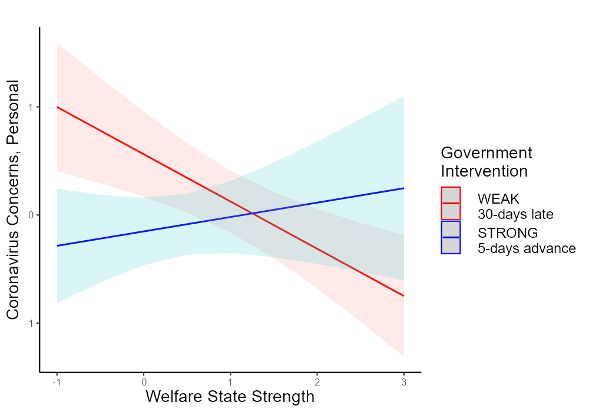

```r
knitr::include_graphics(wdir("COVIDiSTRESS/Fig4.png"))
```

### Fig 5. Margins Plot for Table 3

[output not shown]

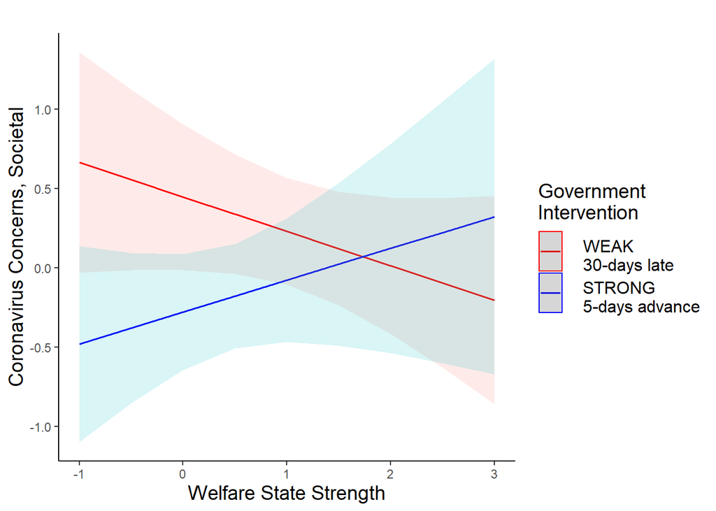

```r
m15plot <- plot_model(m15, type = "pred", terms = c("socpolicy", "intervention [10,-30]"))

m15plot + labs(title = "", x = "Welfare State Strength", y = "Coronavirus Concerns, Societal") +
  scale_color_manual(name="Government\nIntervention",
                       labels=c("WEAK \n30-days late","STRONG \n5-days advance"),
                       values=c("red","blue")) +
    theme(panel.background = element_blank(),
          axis.line = element_line(color = "black"),
          legend.spacing.x = unit(0.5, 'cm'),
          legend.text = element_text(margin = margin(t = 5), size = 12),
          legend.title = element_text(size = 14),
          axis.title = element_text(size = 14))
```

### Table 2a. Table 2 With Outlier Countries.

```r
m1a <- lm(concern_self ~ days_since_peak + conf_delta, data = finaldf_Ca)
m2a <- lm(concern_self ~ days_since_peak + conf_delta + gdp, data = finaldf_Ca)
m3a <- lm(concern_self ~ days_since_peak + conf_delta + socpolicy, data = finaldf_Ca)
m4a <- lm(concern_self ~ days_since_peak + conf_delta + intervention*gdp, data = finaldf_C)
m5a <- lm(concern_self ~ days_since_peak + conf_delta + intervention*socpolicy, data = finaldf_Ca)

tab_model(m1a, m2a, m3a, m4a, m5a, p.style = "stars", p.threshold = c(0.10, 0.05, 0.01), show.ci = F, rm.terms = c("(Intercept)"),  dv.labels = c("M1", "M2","M3","M4", "M5"), pred.labels = c("Days Since Curve Inflection", "New Cases",  "GDP", "Welfare State Strength", "Government Intervention", "Intervention*GDP", "Intervention*Welfare State"), file = wdir("Tbl2.html"))
```

M1

M2

M3

M4

M5

Predictors

Estimates

Estimates

Estimates

Estimates

Estimates

Days Since Curve Inflection

-0.00 **

-0.00

-0.00

-0.01 **

-0.00 **

New Cases

0.19 ***

0.18 ***

0.19 ***

0.50 **

0.24 ***

GDP

-0.00

-0.01

Welfare State Strength

-0.07 *

-0.00

Government Intervention

-0.02

0.01 ***

Intervention*GDP

0.00

Intervention*Welfare State

-0.01 ***

Observations

74

74

74

70

74

R<sup>2</sup> / R<sup>2</sup> adjusted

0.227 / 0.205

0.243 / 0.211

0.259 / 0.228

0.319 / 0.266

0.366 / 0.320

- p<0.1 ** p<0.05 *** p<0.01

### Table 3a. Table 3 With Outlier Countries.

```r
m11a <- lm(concern_society ~ days_since_peak + conf_delta, data = finaldf_Ca)
m12a <- lm(concern_society ~ days_since_peak + conf_delta + gdp + socpolicy, data = finaldf_Ca)
m13a <- lm(concern_society ~ days_since_peak + conf_delta + socpolicy, data = finaldf_Ca)
m14a <- lm(concern_society ~ days_since_peak + conf_delta + intervention*gdp, data = finaldf_Ca)
m15a <- lm(concern_society ~ days_since_peak + conf_delta + intervention*socpolicy, data = finaldf_Ca)

tab_model(m11a, m12a, m13a, m14a, m15a, p.style = "stars", p.threshold = c(0.10, 0.05, 0.01), show.ci = F, rm.terms = c("(Intercept)"),  dv.labels = c("M1", "M2","M3","M4", "M5"), pred.labels = c("Days Since Curve Inflection", "New Cases",  "GDP", "Welfare State Strength", "Government Intervention", "Intervention*GDP", "Intervention*Welfare State"))
```

M1

M2

M3

M4

M5

Predictors

Estimates

Estimates

Estimates

Estimates

Estimates

Days Since Curve Inflection

-0.00

-0.00

-0.00

-0.00

-0.00

New Cases

0.11 *

0.11 *

0.11 *

0.12 *

0.14 **

GDP

0.00

-0.00

Welfare State Strength

-0.01

-0.01

0.03

Government Intervention

0.00

0.01 **

Intervention*GDP

-0.00

Intervention*Welfare State

-0.00 **

Observations

74

74

74

74

74

R<sup>2</sup> / R<sup>2</sup> adjusted

0.058 / 0.032

0.059 / 0.004

0.059 / 0.018

0.085 / 0.017

0.140 / 0.077

- p<0.1 ** p<0.05 *** p<0.01